# Lab 6.1

2026-01-24

## Learning Goals

*At the end of this exercise, you will be able to:*  
1. Use `distinct()` to find unique observations in rows.  
2. Use `mutate()` to create new columns from existing columns.  
3. Use `mutate()` with `across` and `where` to transform multiple columns that meet specific criteria. 4. Use `if_else()` to conditionally change values in a column. 5. Clean data using `janitor` and `mutate()`.

## Load the tidyverse

```r
library("tidyverse")
library("janitor")
library("palmerpenguins") #load the palmerpenguins package
options(scipen=999) #turn off scientific notation
```

## Palmerpenguins

These data are from: Gorman KB, Williams TD, Fraser WR (2014). Ecological sexual dimorphism and environmental variability within a community of Antarctic penguins (genus *Pygoscelis*). PLoS ONE 9(3):e90081. https://doi.org/10.1371/journal.pone.0090081

## Review & Practice

Recall that the the verbs `select()` and `filter()` are used to extract columns and rows from a dataframe. We use the pipe operator `%>%` to connect multiple functions together.

1. Select species, island, and body mass from the penguins data. Arrange results by body mass.

```r
names(penguins)
```

```
## [1] "species"           "island"            "bill_length_mm"
## [4] "bill_depth_mm"     "flipper_length_mm" "body_mass_g"
## [7] "sex"               "year"
```

```r
penguins %>%
  select(species, island, body_mass_g) %>%
  arrange(desc(body_mass_g))
```

```
## # A tibble: 344 × 3
##    species island body_mass_g
##    <fct>   <fct>        <int>
##  1 Gentoo  Biscoe        6300
##  2 Gentoo  Biscoe        6050
##  3 Gentoo  Biscoe        6000
##  4 Gentoo  Biscoe        6000
##  5 Gentoo  Biscoe        5950
##  6 Gentoo  Biscoe        5950
##  7 Gentoo  Biscoe        5850
##  8 Gentoo  Biscoe        5850
##  9 Gentoo  Biscoe        5850
## 10 Gentoo  Biscoe        5800
## # ℹ 334 more rows
```

2. Filter the penguins data to only include observations from Biscoe and Dream islands.

```r
penguins %>%
  select(species, island, body_mass_g) %>%
  filter(island=="Biscoe"|island=="Dream")
```

```
## # A tibble: 292 × 3
##    species island body_mass_g
##    <fct>   <fct>        <int>
##  1 Adelie  Biscoe        3400
##  2 Adelie  Biscoe        3600
##  3 Adelie  Biscoe        3800
##  4 Adelie  Biscoe        3950
##  5 Adelie  Biscoe        3800
##  6 Adelie  Biscoe        3800
##  7 Adelie  Biscoe        3550
##  8 Adelie  Biscoe        3200
##  9 Adelie  Biscoe        3150
## 10 Adelie  Biscoe        3950
## # ℹ 282 more rows
```

```r
penguins %>%
  select(species, island, body_mass_g) %>%
  filter(island==c("Biscoe","Dream"))
```

```
## # A tibble: 146 × 3
##    species island body_mass_g
##    <fct>   <fct>        <int>
##  1 Adelie  Biscoe        3400
##  2 Adelie  Biscoe        3800
##  3 Adelie  Biscoe        3800
##  4 Adelie  Biscoe        3550
##  5 Adelie  Biscoe        3150
##  6 Adelie  Dream         3900
##  7 Adelie  Dream         3900
##  8 Adelie  Dream         4150
##  9 Adelie  Dream         3550
## 10 Adelie  Dream         4650
## # ℹ 136 more rows
```

```r
penguins %>%
  select(species, island, body_mass_g) %>%
  filter(island %in% c("Biscoe","Dream"))
```

```
## # A tibble: 292 × 3
##    species island body_mass_g
##    <fct>   <fct>        <int>
##  1 Adelie  Biscoe        3400
##  2 Adelie  Biscoe        3600
##  3 Adelie  Biscoe        3800
##  4 Adelie  Biscoe        3950
##  5 Adelie  Biscoe        3800
##  6 Adelie  Biscoe        3800
##  7 Adelie  Biscoe        3550
##  8 Adelie  Biscoe        3200
##  9 Adelie  Biscoe        3150
## 10 Adelie  Biscoe        3950
## # ℹ 282 more rows
```

3. Make a plot that shows the relationship between body mass and flipper length. How does this compare among different species?

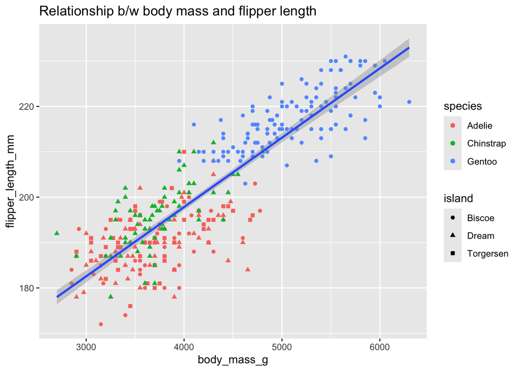

```r
penguins %>%
  ggplot(mapping = aes(x=body_mass_g,y=flipper_length_mm))+
  geom_point(mapping = aes(colour = species, shape = island))+
  geom_smooth(method = lm,se=T)+
  labs(title="Relationship b/w body mass and flipper length")
```

## `distinct()`

`distinct()` looks for all unique observations in rows. This is a little tricky because it can look like it is working column-wise, but it is actually working row-wise.

One helpful approach to new data is to find any duplicated rows. If we first look at the dimensions of the penguins data, we see it has 344 rows and 8 columns.

```r
glimpse(penguins)
```

```
## Rows: 344
## Columns: 8
## $ species           <fct> Adelie, Adelie, Adelie, Adelie, Adelie, Adelie, Adel…
## $ island            <fct> Torgersen, Torgersen, Torgersen, Torgersen, Torgerse…
## $ bill_length_mm    <dbl> 39.1, 39.5, 40.3, NA, 36.7, 39.3, 38.9, 39.2, 34.1, …
## $ bill_depth_mm     <dbl> 18.7, 17.4, 18.0, NA, 19.3, 20.6, 17.8, 19.6, 18.1, …
## $ flipper_length_mm <int> 181, 186, 195, NA, 193, 190, 181, 195, 193, 190, 186…
## $ body_mass_g       <int> 3750, 3800, 3250, NA, 3450, 3650, 3625, 4675, 3475, …
## $ sex               <fct> male, female, female, NA, female, male, female, male…
## $ year              <int> 2007, 2007, 2007, 2007, 2007, 2007, 2007, 2007, 2007…
```

```r
summary(penguins)
```

```
##       species          island    bill_length_mm  bill_depth_mm
##  Adelie   :152   Biscoe   :168   Min.   :32.10   Min.   :13.10
##  Chinstrap: 68   Dream    :124   1st Qu.:39.23   1st Qu.:15.60
##  Gentoo   :124   Torgersen: 52   Median :44.45   Median :17.30
##                                  Mean   :43.92   Mean   :17.15
##                                  3rd Qu.:48.50   3rd Qu.:18.70
##                                  Max.   :59.60   Max.   :21.50
##                                  NA's   :2       NA's   :2
##  flipper_length_mm  body_mass_g       sex           year
##  Min.   :172.0     Min.   :2700   female:165   Min.   :2007
##  1st Qu.:190.0     1st Qu.:3550   male  :168   1st Qu.:2007
##  Median :197.0     Median :4050   NA's  : 11   Median :2008
##  Mean   :200.9     Mean   :4202                Mean   :2008
##  3rd Qu.:213.0     3rd Qu.:4750                3rd Qu.:2009
##  Max.   :231.0     Max.   :6300                Max.   :2009
##  NA's   :2         NA's   :2
```

Using `distinct()` across all rows, we see there are no duplicates. This means every row contains unique observations across all variables.

```r
penguins %>%
  distinct()
```

```
## # A tibble: 344 × 8
##    species island    bill_length_mm bill_depth_mm flipper_length_mm body_mass_g
##    <fct>   <fct>              <dbl>         <dbl>             <int>       <int>
##  1 Adelie  Torgersen           39.1          18.7               181        3750
##  2 Adelie  Torgersen           39.5          17.4               186        3800
##  3 Adelie  Torgersen           40.3          18                 195        3250
##  4 Adelie  Torgersen           NA            NA                  NA          NA
##  5 Adelie  Torgersen           36.7          19.3               193        3450
##  6 Adelie  Torgersen           39.3          20.6               190        3650
##  7 Adelie  Torgersen           38.9          17.8               181        3625
##  8 Adelie  Torgersen           39.2          19.6               195        4675
##  9 Adelie  Torgersen           34.1          18.1               193        3475
## 10 Adelie  Torgersen           42            20.2               190        4250
## # ℹ 334 more rows
## # ℹ 2 more variables: sex <fct>, year <int>
```

But if we only look at species, we can see that there are only 3 unique species in the data.

```r
penguins %>%
  distinct(species)
```

```
## # A tibble: 3 × 1
##   species
##   <fct>
## 1 Adelie
## 2 Gentoo
## 3 Chinstrap
```

What if we want to know which islands each species occurs on?

```r
penguins %>%
  distinct(species, island,.keep_all=T) ## .? keep_all?
```

```
## # A tibble: 5 × 8
##   species   island    bill_length_mm bill_depth_mm flipper_length_mm body_mass_g
##   <fct>     <fct>              <dbl>         <dbl>             <int>       <int>
## 1 Adelie    Torgersen           39.1          18.7               181        3750
## 2 Adelie    Biscoe              37.8          18.3               174        3400
## 3 Adelie    Dream               39.5          16.7               178        3250
## 4 Gentoo    Biscoe              46.1          13.2               211        4500
## 5 Chinstrap Dream               46.5          17.9               192        3500
## # ℹ 2 more variables: sex <fct>, year <int>
```

## `mutate()`

`mutate()` is another verb that acts on columns. It allows us to create new columns from existing columns in a data frame. When we use `mutate()`, the columns are added to the end of the dataframe by default. Let’s create a new column that converts body mass from grams to kilograms.

```r
penguins %>%
  mutate(body_mass_kg=body_mass_g/1000) %>%
  select(species, body_mass_kg, body_mass_g) %>%
  arrange(body_mass_kg)
```

```
## # A tibble: 344 × 3
##    species   body_mass_kg body_mass_g
##    <fct>            <dbl>       <int>
##  1 Chinstrap         2.7         2700
##  2 Adelie            2.85        2850
##  3 Adelie            2.85        2850
##  4 Adelie            2.9         2900
##  5 Adelie            2.9         2900
##  6 Adelie            2.9         2900
##  7 Chinstrap         2.9         2900
##  8 Adelie            2.92        2925
##  9 Adelie            2.98        2975
## 10 Adelie            3           3000
## # ℹ 334 more rows
```

## `mutate()` and `across()`

We use `across()` within `mutate()` to apply a function to multiple columns. This is especially helpful when cleaning data. For example, let’s say we want to convert all columns that end with `mm` to centimeters. We can use `across()` to do this.

```r
penguins %>%
  mutate(across(ends_with("mm"),~./10)) %>%
  select(species, bill_length_cm=bill_length_mm,bill_depth_cm=bill_depth_mm,flipper_length_cm=flipper_length_mm)
```

```
## # A tibble: 344 × 4
##    species bill_length_cm bill_depth_cm flipper_length_cm
##    <fct>            <dbl>         <dbl>             <dbl>
##  1 Adelie            3.91          1.87              18.1
##  2 Adelie            3.95          1.74              18.6
##  3 Adelie            4.03          1.8               19.5
##  4 Adelie           NA            NA                 NA
##  5 Adelie            3.67          1.93              19.3
##  6 Adelie            3.93          2.06              19
##  7 Adelie            3.89          1.78              18.1
##  8 Adelie            3.92          1.96              19.5
##  9 Adelie            3.41          1.81              19.3
## 10 Adelie            4.2           2.02              19
## # ℹ 334 more rows
```

What does the `~./10` mean? The `~` indicates that what follows is a formula (lambda function). The `.` represents the current column being processed. So, `./10` means “take the current column and divide it by 10”. This operation is applied to all columns that end with `mm`.

## Cleaning Data

Cleaning raw data is an essential, but tedious step in data analysis. It’s impossible to predict every scenario that you will come across, but there are some common issues that we can learn to address.

We already learned how to use `rename()` to change column names. We also learned how to rename columns from within `select()`. But, this can be very inefficient if we have a large dataset.

Let’s have a look at some new data focused on mammal lifehistories. The data are from: S. K. Morgan Ernest. 2003. Life history characteristics of placental non-volant mammals. Ecology 84:3402. [link](http://esapubs.org/archive/ecol/E084/093/)

```r
mammals <- read.csv("data/mammal_lifehistories_v2.csv") %>%
  clean_names()
```

What is the structure of the data? Are there any NA’s or other issues?

```r
glimpse(mammals)
```

```
## Rows: 1,440
## Columns: 13
## $ order        <chr> "Artiodactyla", "Artiodactyla", "Artiodactyla", "Artiodac…
## $ family       <chr> "Antilocapridae", "Bovidae", "Bovidae", "Bovidae", "Bovid…
## $ genus        <chr> "Antilocapra", "Addax", "Aepyceros", "Alcelaphus", "Ammod…
## $ species      <chr> "americana", "nasomaculatus", "melampus", "buselaphus", "…
## $ mass         <dbl> 45375.0, 182375.0, 41480.0, 150000.0, 28500.0, 55500.0, 3…
## $ gestation    <dbl> 8.13, 9.39, 6.35, 7.90, 6.80, 5.08, 5.72, 5.50, 8.93, 9.1…
## $ newborn      <dbl> 3246.36, 5480.00, 5093.00, 10166.67, -999.00, 3810.00, 39…
## $ weaning      <dbl> 3.00, 6.50, 5.63, 6.50, -999.00, 4.00, 4.04, 2.13, 10.71,…
## $ wean_mass    <dbl> 8900, -999, 15900, -999, -999, -999, -999, -999, 157500, …
## $ afr          <dbl> 13.53, 27.27, 16.66, 23.02, -999.00, 14.89, 10.23, 20.13,…
## $ max_life     <int> 142, 308, 213, 240, -999, 251, 228, 255, 300, 324, 300, 3…
## $ litter_size  <dbl> 1.85, 1.00, 1.00, 1.00, 1.00, 1.37, 1.00, 1.00, 1.00, 1.0…
## $ litters_year <dbl> 1.00, 0.99, 0.95, -999.00, -999.00, 2.00, -999.00, 1.89, …
```

```r
mammals <- mammals %>%
  clean_names()
```

Notice that `clean_names()` has converted all column names to lowercase and replaced spaces with underscores. But, no adjustments were made to the data itself. What if we want to change observations from upper case to lower case?

```r
mammals %>%
  mutate(across(c("order","family"), tolower)) # specific col
```

```
##               order          family            genus           species
## 1      artiodactyla  antilocapridae      Antilocapra         americana
## 2      artiodactyla         bovidae            Addax     nasomaculatus
## 3      artiodactyla         bovidae        Aepyceros          melampus
## 4      artiodactyla         bovidae       Alcelaphus        buselaphus
## 5      artiodactyla         bovidae       Ammodorcas           clarkei
## 6      artiodactyla         bovidae       Ammotragus            lervia
## 7      artiodactyla         bovidae       Antidorcas       marsupialis
## 8      artiodactyla         bovidae         Antilope        cervicapra
## 9      artiodactyla         bovidae            Bison             bison
## 10     artiodactyla         bovidae            Bison           bonasus
## 11     artiodactyla         bovidae              Bos         grunniens
## 12     artiodactyla         bovidae              Bos         frontalis
## 13     artiodactyla         bovidae              Bos         javanicus
## 14     artiodactyla         bovidae       Boselaphus      tragocamelus
```

[output cut: 4308 more lines]

This will change all columns to lower case. But, notice what happens to numeric columns.

```r
mammals %>%
  mutate(across(everything(), tolower)) #problem: numeric -> character
```

```
##               order          family            genus           species
## 1      artiodactyla  antilocapridae      antilocapra         americana
## 2      artiodactyla         bovidae            addax     nasomaculatus
## 3      artiodactyla         bovidae        aepyceros          melampus
## 4      artiodactyla         bovidae       alcelaphus        buselaphus
## 5      artiodactyla         bovidae       ammodorcas           clarkei
## 6      artiodactyla         bovidae       ammotragus            lervia
## 7      artiodactyla         bovidae       antidorcas       marsupialis
## 8      artiodactyla         bovidae         antilope        cervicapra
## 9      artiodactyla         bovidae            bison             bison
## 10     artiodactyla         bovidae            bison           bonasus
## 11     artiodactyla         bovidae              bos         grunniens
## 12     artiodactyla         bovidae              bos         frontalis
## 13     artiodactyla         bovidae              bos         javanicus
## 14     artiodactyla         bovidae       boselaphus      tragocamelus
```

[output cut: 4308 more lines]

For this reason, it might be better to use `where` so we can specify only character columns.

```r
mammals %>%
  mutate(across(where(is.character), tolower))
```

```
##               order          family            genus           species
## 1      artiodactyla  antilocapridae      antilocapra         americana
## 2      artiodactyla         bovidae            addax     nasomaculatus
## 3      artiodactyla         bovidae        aepyceros          melampus
## 4      artiodactyla         bovidae       alcelaphus        buselaphus
## 5      artiodactyla         bovidae       ammodorcas           clarkei
## 6      artiodactyla         bovidae       ammotragus            lervia
## 7      artiodactyla         bovidae       antidorcas       marsupialis
## 8      artiodactyla         bovidae         antilope        cervicapra
## 9      artiodactyla         bovidae            bison             bison
## 10     artiodactyla         bovidae            bison           bonasus
## 11     artiodactyla         bovidae              bos         grunniens
## 12     artiodactyla         bovidae              bos         frontalis
## 13     artiodactyla         bovidae              bos         javanicus
## 14     artiodactyla         bovidae       boselaphus      tragocamelus
```

[output cut: 4308 more lines]

## `if_else()`

We briefly introduce `if_else()` here because it allows us to use `mutate()` but not have the entire column affected in the same way. With `ifelse()`, you first specify a logical statement, afterwards what needs to happen if the statement returns `TRUE`, and lastly what needs to happen if it’s `FALSE`.

Have a look at the data from mammals below. Notice that the values for newborn include `-999.00`. This is sometimes used as a placeholder for NA (but, is a really bad idea). We can use `if_else()` to replace `-999.00` with `NA`.

```r
summary(mammals)
```

```
##     order              family             genus             species
##  Length:1440        Length:1440        Length:1440        Length:1440
##  Class :character   Class :character   Class :character   Class :character
##  Mode  :character   Mode  :character   Mode  :character   Mode  :character
##
##
##
##       mass             gestation          newborn              weaning
##  Min.   :     -999   Min.   :-999.00   Min.   :   -999.00   Min.   :-999.00
##  1st Qu.:       50   1st Qu.:-999.00   1st Qu.:   -999.00   1st Qu.:-999.00
##  Median :      403   Median :   1.05   Median :      2.65   Median :   0.73
##  Mean   :   383577   Mean   :-287.25   Mean   :   6703.15   Mean   :-427.17
##  3rd Qu.:     7009   3rd Qu.:   4.50   3rd Qu.:     98.00   3rd Qu.:   2.00
##  Max.   :149000000   Max.   :  21.46   Max.   :2250000.00   Max.   :  48.00
##    wean_mass             afr             max_life       litter_size
##  Min.   :    -999   Min.   :-999.00   Min.   :-999.0   Min.   :-999.000
##  1st Qu.:    -999   1st Qu.:-999.00   1st Qu.:-999.0   1st Qu.:   1.000
##  Median :    -999   Median :   2.50   Median :-999.0   Median :   2.270
##  Mean   :   16049   Mean   :-408.12   Mean   :-490.3   Mean   : -55.634
##  3rd Qu.:      10   3rd Qu.:  15.61   3rd Qu.: 147.2   3rd Qu.:   3.835
##  Max.   :19075000   Max.   : 210.00   Max.   :1368.0   Max.   :  14.180
##   litters_year
##  Min.   :-999.000
##  1st Qu.:-999.000
##  Median :   0.375
##  Mean   :-477.141
##  3rd Qu.:   1.155
##  Max.   :   7.500
```

```r
mammals %>%
  select(genus, species, newborn) %>%
  arrange(newborn)
```

```
##                 genus           species    newborn
## 1          Ammodorcas           clarkei    -999.00
## 2                 Bos         javanicus    -999.00
## 3             Bubalus    depressicornis    -999.00
## 4             Bubalus       mindorensis    -999.00
## 5               Capra         falconeri    -999.00
## 6         Cephalophus             niger    -999.00
## 7         Cephalophus        nigrifrons    -999.00
## 8         Cephalophus        natalensis    -999.00
## 9         Cephalophus       leucogaster    -999.00
## 10        Cephalophus           ogilbyi    -999.00
## 11            Gazella     soemmerringii    -999.00
## 12            Gazella         rufifrons    -999.00
## 13            Gazella              dama    -999.00
## 14            Gazella           cuvieri    -999.00
```

[output cut: 1426 more lines]

```r
mammals %>%
  select(genus, species, newborn) %>%
  mutate(newborn_new=ifelse(newborn == -999.00, NA, newborn))
```

```
##                 genus           species    newborn newborn_new
## 1         Antilocapra         americana    3246.36     3246.36
## 2               Addax     nasomaculatus    5480.00     5480.00
## 3           Aepyceros          melampus    5093.00     5093.00
## 4          Alcelaphus        buselaphus   10166.67    10166.67
## 5          Ammodorcas           clarkei    -999.00          NA
## 6          Ammotragus            lervia    3810.00     3810.00
## 7          Antidorcas       marsupialis    3910.00     3910.00
## 8            Antilope        cervicapra    3846.00     3846.00
## 9               Bison             bison   20000.00    20000.00
## 10              Bison           bonasus   23000.08    23000.08
## 11                Bos         grunniens   18000.00    18000.00
## 12                Bos         frontalis   23033.33    23033.33
## 13                Bos         javanicus    -999.00          NA
## 14         Boselaphus      tragocamelus    5875.00     5875.00
```

[output cut: 1426 more lines]

## Practice

1. Following the example above, convert all -999 values in the mammals dataframe to NA.

```r
glimpse(mammals)
```

```
## Rows: 1,440
## Columns: 13
## $ order        <chr> "Artiodactyla", "Artiodactyla", "Artiodactyla", "Artiodac…
## $ family       <chr> "Antilocapridae", "Bovidae", "Bovidae", "Bovidae", "Bovid…
## $ genus        <chr> "Antilocapra", "Addax", "Aepyceros", "Alcelaphus", "Ammod…
## $ species      <chr> "americana", "nasomaculatus", "melampus", "buselaphus", "…
## $ mass         <dbl> 45375.0, 182375.0, 41480.0, 150000.0, 28500.0, 55500.0, 3…
## $ gestation    <dbl> 8.13, 9.39, 6.35, 7.90, 6.80, 5.08, 5.72, 5.50, 8.93, 9.1…
## $ newborn      <dbl> 3246.36, 5480.00, 5093.00, 10166.67, -999.00, 3810.00, 39…
## $ weaning      <dbl> 3.00, 6.50, 5.63, 6.50, -999.00, 4.00, 4.04, 2.13, 10.71,…
## $ wean_mass    <dbl> 8900, -999, 15900, -999, -999, -999, -999, -999, 157500, …
## $ afr          <dbl> 13.53, 27.27, 16.66, 23.02, -999.00, 14.89, 10.23, 20.13,…
## $ max_life     <int> 142, 308, 213, 240, -999, 251, 228, 255, 300, 324, 300, 3…
## $ litter_size  <dbl> 1.85, 1.00, 1.00, 1.00, 1.00, 1.37, 1.00, 1.00, 1.00, 1.0…
## $ litters_year <dbl> 1.00, 0.99, 0.95, -999.00, -999.00, 2.00, -999.00, 1.89, …
```

```r
mammals <- mammals %>%
  mutate(across(c(mass,gestation, max_life, newborn, weaning, litter_size, afr, litters_year), ~ifelse(.==-999, NA,.)))
```

2. In the mammals data, make a new column `mass_kg` that that converts mass from grams to kilograms. Select the columns genus, species, mass, and mass_kg, and arrange the data by mass_kg in descending order. What is the common name for the species with the highest mass?

```r
names(mammals)
```

```
##  [1] "order"        "family"       "genus"        "species"      "mass"
##  [6] "gestation"    "newborn"      "weaning"      "wean_mass"    "afr"
## [11] "max_life"     "litter_size"  "litters_year"
```

```r
glimpse(mammals)
```

```
## Rows: 1,440
## Columns: 13
## $ order        <chr> "Artiodactyla", "Artiodactyla", "Artiodactyla", "Artiodac…
## $ family       <chr> "Antilocapridae", "Bovidae", "Bovidae", "Bovidae", "Bovid…
## $ genus        <chr> "Antilocapra", "Addax", "Aepyceros", "Alcelaphus", "Ammod…
## $ species      <chr> "americana", "nasomaculatus", "melampus", "buselaphus", "…
## $ mass         <dbl> 45375.0, 182375.0, 41480.0, 150000.0, 28500.0, 55500.0, 3…
## $ gestation    <dbl> 8.13, 9.39, 6.35, 7.90, 6.80, 5.08, 5.72, 5.50, 8.93, 9.1…
## $ newborn      <dbl> 3246.36, 5480.00, 5093.00, 10166.67, NA, 3810.00, 3910.00…
## $ weaning      <dbl> 3.00, 6.50, 5.63, 6.50, NA, 4.00, 4.04, 2.13, 10.71, 6.60…
## $ wean_mass    <dbl> 8900, -999, 15900, -999, -999, -999, -999, -999, 157500, …
## $ afr          <dbl> 13.53, 27.27, 16.66, 23.02, NA, 14.89, 10.23, 20.13, 29.4…
## $ max_life     <int> 142, 308, 213, 240, NA, 251, 228, 255, 300, 324, 300, 314…
## $ litter_size  <dbl> 1.85, 1.00, 1.00, 1.00, 1.00, 1.37, 1.00, 1.00, 1.00, 1.0…
## $ litters_year <dbl> 1.00, 0.99, 0.95, NA, NA, 2.00, NA, 1.89, 1.00, 1.00, 0.7…
```

```r
mammals %>%
  mutate(mass_kg=mass/1000) %>%
  select(genus, species, mass, mass_kg) %>%
  arrange(desc(mass_kg))
```

```
##                 genus           species         mass      mass_kg
## 1        Balaenoptera          musculus 149000000.00 149000.00000
## 2             Balaena        mysticetus  80000000.00  80000.00000
## 3        Balaenoptera          physalus  66800000.00  66800.00000
## 4           Megaptera      novaeangliae  30000000.00  30000.00000
## 5        Eschrichtius          robustus  25066666.67  25066.66667
## 6           Eubalaena         australis  23000000.00  23000.00000
## 7           Eubalaena         glacialis  23000000.00  23000.00000
## 8        Balaenoptera             edeni  20000000.00  20000.00000
## 9        Balaenoptera     acutorostrata  16266666.67  16266.66667
## 10           Physeter           catodon  15400000.00  15400.00000
## 11       Balaenoptera          borealis  14766666.67  14766.66667
## 12          Berardius           bairdii   8200000.00   8200.00000
## 13         Hyperoodon        ampullatus   5266666.67   5266.66667
## 14            Orcinus              orca   4300000.00   4300.00000
```

[output cut: 1426 more lines]

3. What is the relationship between gestation and newborn mass?

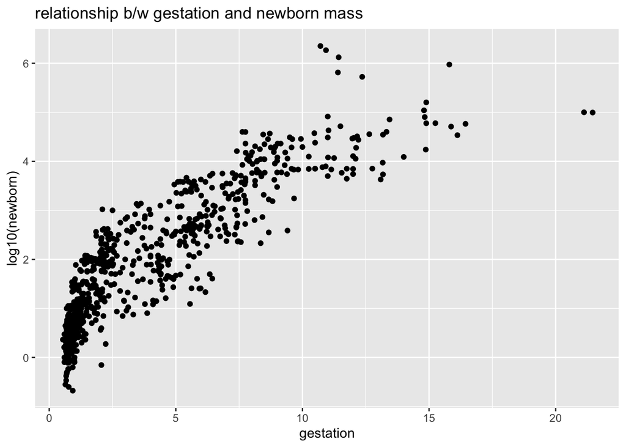

```r
mammals %>%
  ggplot(mapping = aes(x=gestation, y=log10(newborn)))+
  geom_point()+
  labs(title="relationship b/w gestation and newborn mass")
```

4. Which mammal has the longest life span in years?

```r
mammals %>%
  select(genus, species, max_life) %>%
  mutate(max_life_new=max_life/12) %>%
  arrange((desc(max_life_new)))
```

```
##                 genus           species max_life max_life_new
## 1        Balaenoptera          physalus     1368   114.000000
## 2        Balaenoptera          musculus     1320   110.000000
## 3             Balaena        mysticetus     1200   100.000000
## 4             Orcinus              orca     1080    90.000000
## 5           Berardius           bairdii     1008    84.000000
## 6             Elephas           maximus      960    80.000000
## 7           Megaptera      novaeangliae      924    77.000000
## 8            Physeter           catodon      924    77.000000
## 9        Balaenoptera          borealis      888    74.000000
## 10             Dugong             dugon      876    73.000000
## 11       Balaenoptera             edeni      864    72.000000
## 12       Eschrichtius          robustus      840    70.000000
## 13          Loxodonta          africana      840    70.000000
## 14          Eubalaena         glacialis      804    67.000000
```

[output cut: 1426 more lines]

5. Do larger mammals live longer?

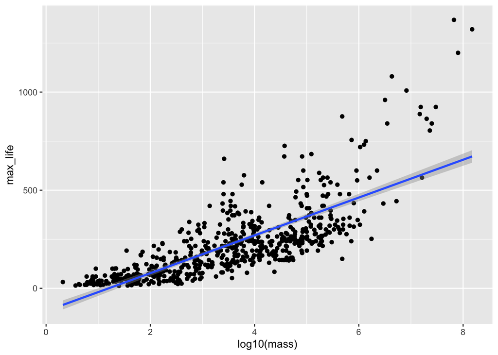

```r
mammals %>%
  ggplot(mapping=aes(x=log10(mass), y=max_life))+
  geom_point()+
  geom_smooth(method="lm")
```

–>[Home](https://jmledford3115.github.io/datascibiol/)